# Homework 5

Sana Khan

2022-11-06

Homework 1 by Sana Khan: I consulted with our textbook to complete these problems.

6**.The PlantGrowth data set contains three different groups, with each representing various plant food diets (you may need to type data(PlantGrowth) to activate it). The group labeled “ctrl” is the control group, while “trt1” and “trt2” are different types of experimental treatment. As a reminder, this subsetting statement accesses the weight data for the control group:**

**PlantGrowth**$weight[PlantGrowth$**group==“ctrl”] and this subsetting statement accesses the weight data for treatment group 1: PlantGrowth**$weight[PlantGrowth$**group==“trt1”]**

**Run a t‐test to compare the means of the control group (“ctrl”) and treatment group 1 (“trt1”) in the PlantGrowth data. Report the observed value of t, the degrees of freedom, and the p‐value associated with the observed value. Assuming an alpha threshold of .05, decide whether you should reject the null hypothesis or fail to reject the null hypothesis. In addition, report the upper and lower bound of the confidence interval.**

```r
data(PlantGrowth)
ctrl <- PlantGrowth$weight[PlantGrowth$group=='ctrl']
trt1 <- PlantGrowth$weight[PlantGrowth$group=='trt1']

t.test(ctrl,trt1)
```

```
##
##  Welch Two Sample t-test
##
## data:  ctrl and trt1
## t = 1.1913, df = 16.524, p-value = 0.2504
## alternative hypothesis: true difference in means is not equal to 0
## 95 percent confidence interval:
##  -0.2875162  1.0295162
## sample estimates:
## mean of x mean of y
##     5.032     4.661
```

The value for T = 1.19, the degrees of freedom = 16.5 and the p-value =.25. The p-value is greater than our alpha, so we fail to reject the null hypothesis. The lower bound of our confidence interval is -.29 and the upper bound is 1.03

7**.Install and library() the BEST package. Note that you may need to install a program called JAGS onto your computer before you try to install the BEST package inside of R. Use BESTmcmc() to compare the PlantGrowth control group (“ctrl”) to treatment group 1 (“trt1”). Plot the result and document the boundary values that BESTmcmc() calculated for the HDI. Write a brief definition of the meaning of the HDI and interpret the results from this comparison.**

```
## Waiting for parallel processing to complete...done.
```

```
## MCMC fit results for BEST analysis:
## 100002 simulations saved.
##           mean      sd  median  HDIlo  HDIup  Rhat n.eff
## mu1     5.0274  0.2253  5.0280 4.5789  5.476 1.000 53748
## mu2     4.6415  0.3080  4.6391 4.0348  5.256 1.000 52581
## nu     34.3912 29.7215 25.7575 1.1637 93.156 1.001 19743
## sigma1  0.6607  0.2027  0.6227 0.3442  1.064 1.000 25740
## sigma2  0.8976  0.2803  0.8450 0.4522  1.457 1.001 24856
##
## 'HDIlo' and 'HDIup' are the limits of a 95% HDI credible interval.
## 'Rhat' is the potential scale reduction factor (at convergence, Rhat=1).
## 'n.eff' is a crude measure of effective sample size.
```

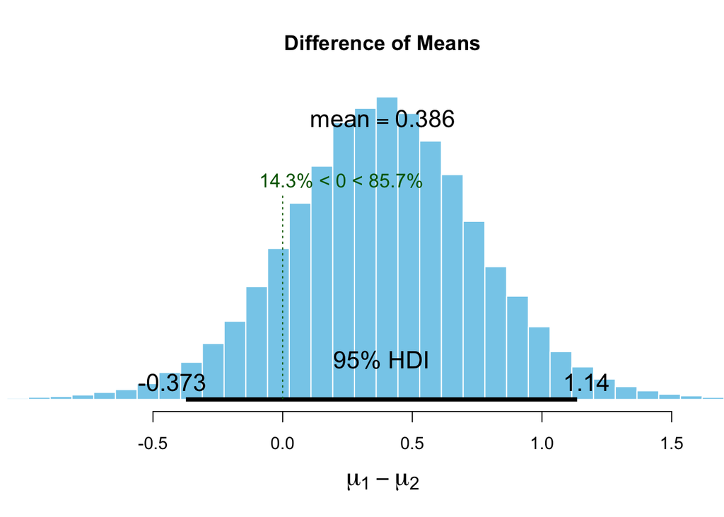

8.**Compare and contrast the results of Exercise 6 and Exercise 7. You have three types of evidence: the results of the null hypothesis test, the confidence interval, and the HDI from the BESTmcmc() procedure. Each one adds something, in turn, to the understanding of the difference between groups. Explain what information each test provides about the comparison of the control group (“ctrl”) and the treatment group 1 (“trt1”).**

9**.Using the same PlantGrowth data set, compare the “ctrl” group to the “trt2” group. Use all of the methods described earlier (t‐test, confidence interval, and Bayesian method) and explain all of the results**.

```r
trt2 <- PlantGrowth$weight[PlantGrowth$group=='trt2']

t.test(ctrl,trt2)
```

```
##
##  Welch Two Sample t-test
##
## data:  ctrl and trt2
## t = -2.134, df = 16.786, p-value = 0.0479
## alternative hypothesis: true difference in means is not equal to 0
## 95 percent confidence interval:
##  -0.98287213 -0.00512787
## sample estimates:
## mean of x mean of y
##     5.032     5.526
```

```r
plantBEST2 <- BESTmcmc(ctrl,trt2)
```

```
## Waiting for parallel processing to complete...done.
```

```r
plantBEST2
```

```
## MCMC fit results for BEST analysis:
## 100002 simulations saved.
##           mean      sd  median  HDIlo   HDIup  Rhat n.eff
## mu1     5.0257  0.2238  5.0267 4.5808  5.4758 1.000 52297
## mu2     5.5138  0.1723  5.5125 5.1736  5.8600 1.000 51396
## nu     34.4675 29.5136 25.9047 1.1662 93.3034 1.003 20200
## sigma1  0.6612  0.2030  0.6228 0.3464  1.0642 1.000 26331
## sigma2  0.5023  0.1558  0.4736 0.2552  0.8138 1.000 25480
##
## 'HDIlo' and 'HDIup' are the limits of a 95% HDI credible interval.
## 'Rhat' is the potential scale reduction factor (at convergence, Rhat=1).
## 'n.eff' is a crude measure of effective sample size.
```

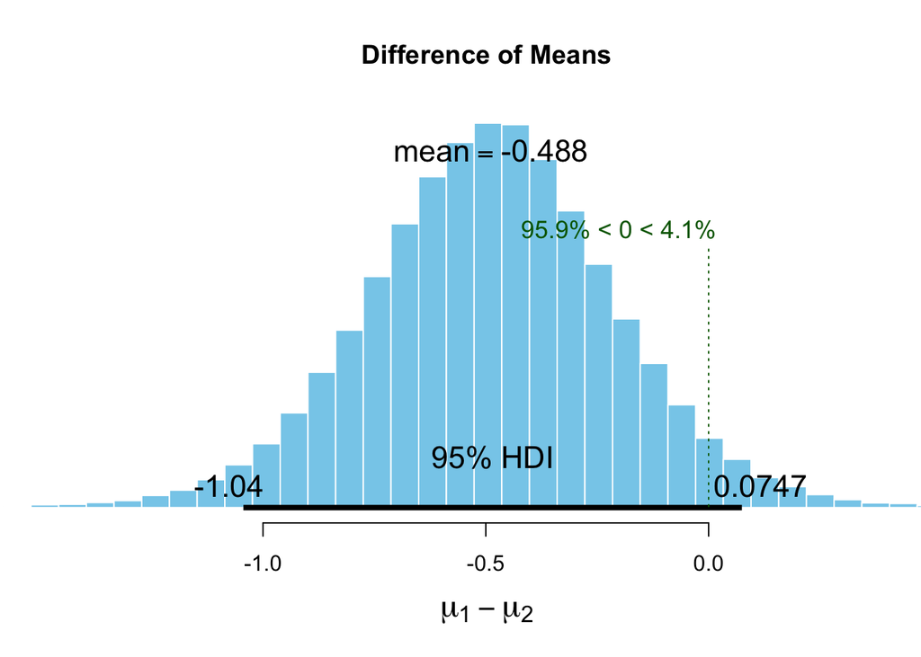

```r
plot(plantBEST2)
```

10. **Consider this t‐test, which compares two groups of n = 100,000 observations each:**

**t.test(rnorm(100000,mean=17.1,sd=3.8),rnorm(100000,mean=17.2,sd=3.8))**

**For each of the groups, the rnorm() command was used to generate a random normal distribution of observations similar to those for the automatic transmission group in the mtcars database (compare the programmed standard deviation for the random normal data to the actual mtcars data). The only difference between the two groups is that in the first rnorm() call, the mean is set to 17.1 mpg and in the second it is set to 17.2 mpg. I think you would agree that this is a negligible difference, if we are discuss‐ ing fuel economy. Run this line of code and comment on the results of the t‐test. What are the implications in terms of using the NHST on very large data sets?**

**t = -6.2855, df = 2e+05, p-value = 3.274e-10 alternative hypothesis: true difference in means is not equal to 0 95 percent confidence interval: -0.14002939 -0.07345877 sample estimates: mean of x mean of y 17.09753 17.20428**

The NHST can be unreliable on large data sets because small changes in the data can impact the results of rejecting or failing to reject the null hypothesis.